# Orthogonalization of U by SVD

## How to orthogonalize efficiently

Consider the problem of computing the SVD of a matrix $UV^\top$. In order to skip the multiplication of matrices, use the QR decomposition:
$$U=U_QU_R$$
where $U_Q$ is orthogonal of the same size as $U$, and $U_R$ is upper triangular $2\times 2$. We have:
$$UV^T=U_QU_RV_R^TV_Q^T,$$
with $U_RV_R^T$ of size $2\times 2$. The SVD of $A:=U_RV_R^T$ is
$$A=A_UA_DA_V^T,$$
with $A_U,A_V$ orthogonals and $A_D$ diagonal matrices. This gives:
$$UV^T=U_QA_UA_DA_V^TV_Q^T=:\tilde{U}\tilde{V}^T,$$
where $\tilde{U}=U_QA_U$ and $\tilde{V}=V_Q A_V A_D$ are orthogonal. To keep the same $UW^T$, modifie $W$:
$$UW^T=U_QU_RW^T=U_QA_UA_U^TU_RW^T=\tilde{U}\tilde{W}^T,$$
with $\tilde{W}=WU_R^TA_U$. JP: in this version we do not need to inverse the diagonal and I do not use “solve” any more.

## Modification (JP)

Let’s remember that we maximize the log-likelihood $\ell(U,V,W)$ penalized by the Frobenius norm of the matrices:
$$\max_{U,V,W} \ell(U,V,W) - \epsilon(||U||^2+||V||^2 + ||W||^2) \,.$$
The likelihood $\ell(U,V,W)$ only depends on $U,V,W$ through $UV^\top$ and $UW^\top$, so we can rewrite our objective function as
$$\max_{U,V,W} f(UV^\top,UW^\top) - \epsilon(||U||^2+||V||^2 + ||W||^2) \,.$$
The regularization is not only beneficial for statistical and numerical reasons, but also has the effect of naturally enforcing orthogonality of columns in the matrices. More precisely, forget about $W$ for a moment and consider the problem
$$\max_{U,V} f(UV^\top) - \epsilon(||U||^2+||V||^2) \,.$$
It is well known that the trace norm of a matrix $M$ (i.e., the sum of singular values) can be expressed as
$$||M||_{\ast} = \min_{UV^\top=M}\left(||U||^2 + ||V||^2\right)$$
so our problem becomes
$$\max_M f(M) - \epsilon ||M||_{\ast} \,,$$
and if $M^*$ denotes the solution of this problem then the $U^*$ and $V^*$ that achieve the maximum are the singular vectors of $M^*$ scaled by the square roots of the singular values: if $M^*=ASB^\top$ is the SVD of $M^*$, then $U^* = A\sqrt(S)$ and $V^*=B\sqrt{S}$. In other words, the optimal $U^*$ and $V^*$ are (scaled) singular vectors of $M$, and in particular have orthogonal columns.

Back to our problem with $W$, the same reasoning applies to the matrices $U$ and $[V;W]$, i.e., at the optimum the columns or U are orthogonal, as well as the columns of $[V,W]$.

In practice we optimize by alternating optimization in $U$ on the one hand, and $[V;W]$ on the other hand. To speed up convergence it can therefore be useful to insert an orthogonalization step between each optimization, where $U$ and $[V;W]$ are set to the scaled singular vectors of the matrix $M = U*[V;W]^\top$; this amounts to minimizing the regularization $(||U||^2+||V||^2 + ||W||^2)$ under the constraint that $\ell(U,V,W)$ does not change, and is obtained by a simple SVD.

This orthogononatization is implemented in the orthogonalizeJointly(U,V,W) function.

Note that the columns of $V$ only have no reason to be orthogonal, neither the columns of $W$ only. Hence the procedure presented in the first paragraph above (enforce orthogonal columns for $U$ and $V$, but not $W$) is not correct, in the sense that it degrades the objective function. This explains why we observed some oscillation in the objective function when we tried it. Instead, when $V$ and $W$ are treated jointly, then the orthogonalization step really corresponds to a partical maximization of the objective function.

## Test of the orthogonalization step

Test on small simulated matrices that this function does what it should

```r
library(zinb)
set.seed(1234)

# random matrices
U <- matrix( rnorm(16), ncol=2 )
V <- matrix( rnorm(20), ncol=2 )
W <- matrix( rnorm(20), ncol=2 )

# orthogonalize them
o <- orthogonalizeJointly(U,V,W)

# Check that UV' is conserved
sum((U%*%t(V) - o$U %*% t(o$V))^2)
```

```
## [1] 9.166656e-30
```

```r
# Check that UW' is conserved
sum((U%*%t(W) - o$U %*% t(o$W))^2)
```

```
## [1] 6.342665e-30
```

```r
# Check that U has orthogonal columns
t(o$U) %*% o$U
```

```
##               [,1]          [,2]
## [1,]  1.581700e+01 -3.122502e-16
## [2,] -3.122502e-16  7.364557e+00
```

```r
# Check that the regularization term has decreased
sum(U^2) + sum(V^2) + sum(W^2)
```

```
## [1] 54.84837
```

```r
sum(o$U^2) + sum(o$V^2) + sum(o$W^2)
```

```
## [1] 46.36311
```

## Test on Fluidigm data

This procedure is included in the function called zinb.PCA.svd. (JP: I also changed initialization to SVD of log(count+1) instead of PCA(logcount+1). Let’s run it on Fluidigm data

```
## Iteration 1
## log-likelihood = -10710928
##    user  system elapsed
## 198.950  14.333  37.690
## log-likelihood = -1814820
##    user  system elapsed
##  40.113   3.443   1.454
## Iteration 2
## log-likelihood = -1794752
##    user  system elapsed
##  85.544   6.508  16.051
## log-likelihood = -1783521
##    user  system elapsed
##  20.337   2.031   1.428
## Iteration 3
## log-likelihood = -1780999
##    user  system elapsed
##  70.407   5.732  12.862
## log-likelihood = -1779590
##    user  system elapsed
##  17.541   1.787   1.349
## Iteration 4
## log-likelihood = -1778511
##    user  system elapsed
##  73.487   6.771  13.999
## log-likelihood = -1777513
##    user  system elapsed
##  17.914   1.931   1.267
## Iteration 5
## log-likelihood = -1776929
##    user  system elapsed
##  67.088   5.383  12.368
## log-likelihood = -1776437
##    user  system elapsed
##  17.115   1.767   1.262
## Iteration 6
## log-likelihood = -1776110
##    user  system elapsed
##  69.686   6.458  13.088
## log-likelihood = -1775797
```

[output cut: 45 more lines]

```
## log-likelihood = -1773404
##    user  system elapsed
##  59.296   5.727  13.017
## log-likelihood = -1773300
##    user  system elapsed
##  28.294   3.046   1.210
## Iteration 14
## log-likelihood = -1773214
##    user  system elapsed
##  68.493   5.131  12.494
## log-likelihood = -1773126
##    user  system elapsed
##  16.241   1.668   1.232
## Iteration 15
## log-likelihood = -1773050
```

Check orthogonality ($U$ has orthogonal columns, but not $V$ or $W$)

```r
t(zinb.orthog$U)%*%zinb.orthog$U
```

```
##               [,1]          [,2]
## [1,]  2.507710e+04 -9.947598e-13
## [2,] -9.947598e-13  6.318567e+03
```

```r
t(zinb.orthog$V)%*%zinb.orthog$V
```

```
##           [,1]      [,2]
## [1,] 23610.179 -1759.763
## [2,] -1759.763  1019.886
```

```r
t(zinb.orthog$W)%*%zinb.orthog$W
```

```
##          [,1]     [,2]
## [1,] 1466.918 1759.763
## [2,] 1759.763 5298.682
```

Plot the result:

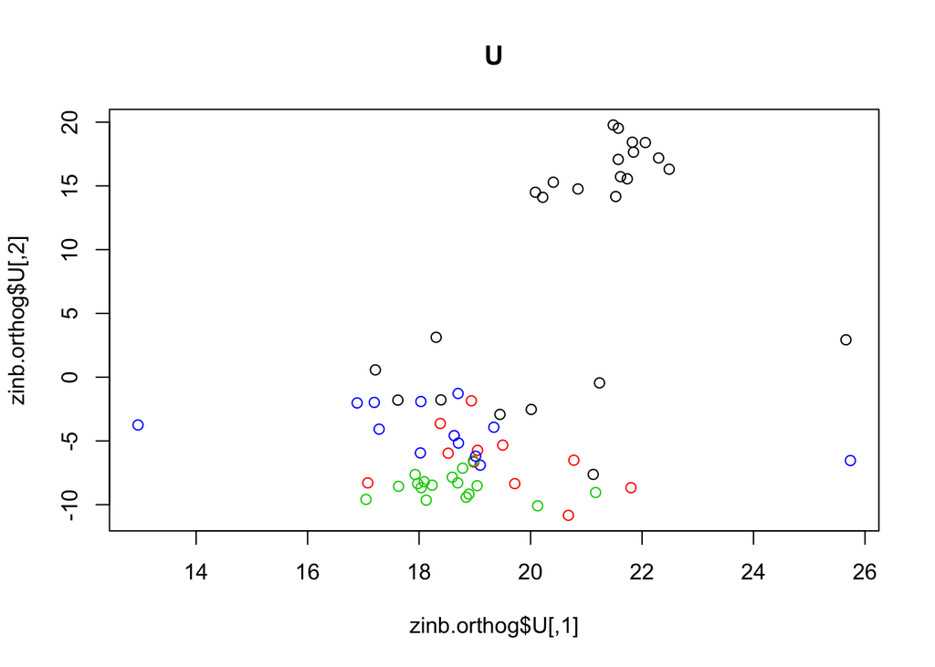

```r
plot(zinb.orthog$U,col=colData(fluidigm)$Cluster2[colData(fluidigm)$Coverage_Type=="High"],main="U")
```

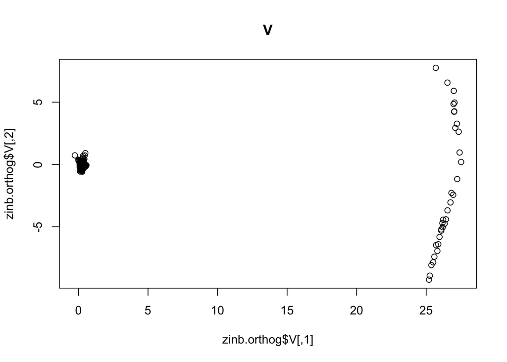

```r
plot(zinb.orthog$V,main="V")
```

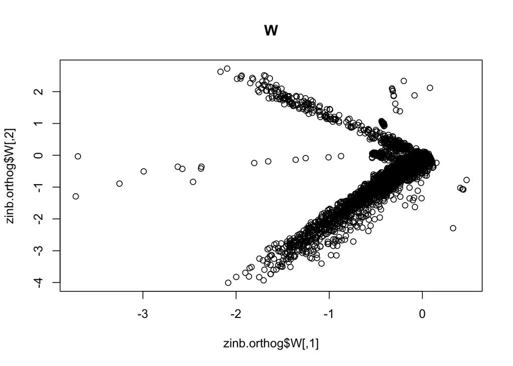

```r
plot(zinb.orthog$W,main="W")
```

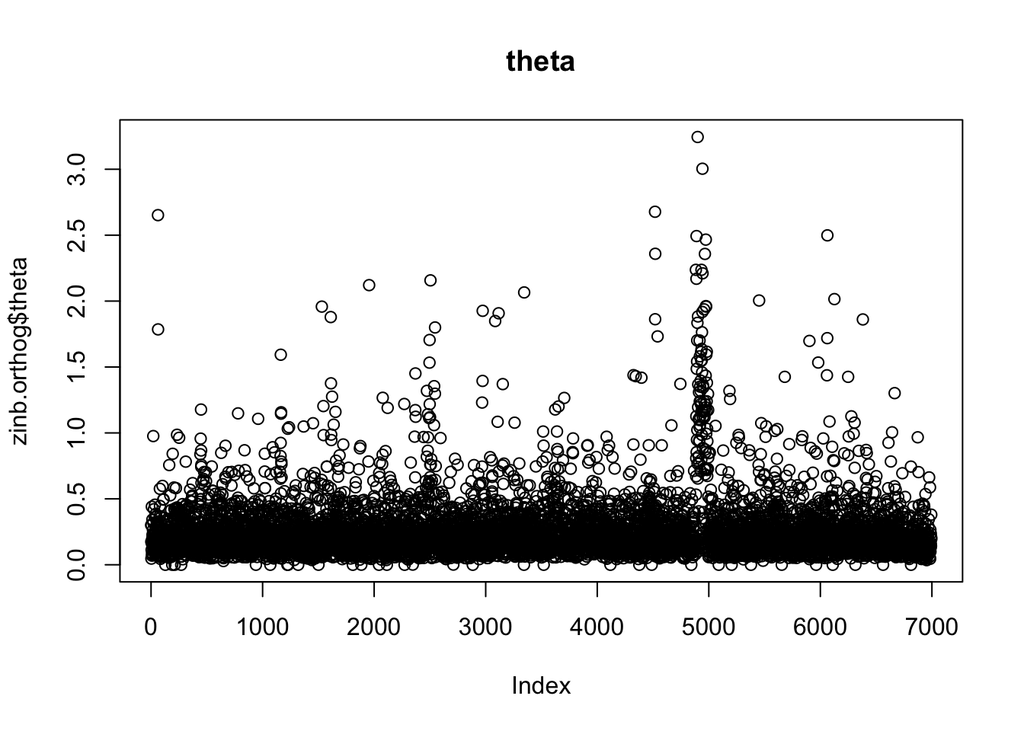

```r
plot(zinb.orthog$theta,main="theta")
```